# Short-term impacts of island restoration on seabirds in Gwaii Haanas

# BACI

Task 2e) Test whether restoration resulted in an increase in seabird vocalization metrics, by species (abundance), using BACI design.

##### Statistical model

We used ANOVA (type 3 with Kenward-Roger approximation for degrees of freedom) to determine statistical significance of fixed effects. The interaction term (period:siteclass) is the ‘BACI effect’ and indicates a difference in before-after response for control and impact groups. For all coefficients, a p-value < 0.05 indicated statistical significance. We also determined the magnitude of the BACI effect (contrast) by calculating the difference of the differences in marginal means (uCA = uCB - uIA + uIB) along with 95% confidence limits; these analyses were done using the lsmeans package. The contrast can be interpreted as percent increase in the response in the impact area relative the the control area; confidence limits not including 0 indicate an effect.

Key assumptions of the model:

- System is in equilibirum before and after impact.
  - This assumption may not be valid as recovery of seabird breeding population may occur over a longer time period than is accounted for in this study.
- Variance is homogeneous, data are normally distributed.
  - We used several diagnostic plots (residuals vs. fitted values, qqplot for normality) to test validity of the statistical model and associated p-values.
- Observations are independent within each site-year combination and across years.
  - Sites were spaced sufficeintly far apart in space to warrant assumption of independence.

## Ancient Murrelet

Figure 1: Phase 1 temporal coverage by site. Colour indicates site class (‘Control’, ‘Impact’). Vertical black lines indicate 2-week sampling window used for Ancient Murrelet analysis (May 11 - May 24)

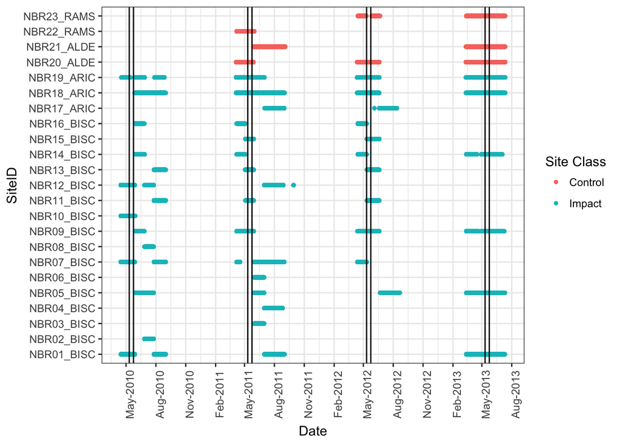

Figure 2: Phase 2 temporal coverage by site. Colour indicates site class (‘Control’, ‘Impact’). Vertical black lines indicate 2-week sampling window used for Ancient Murrelet analysis (May 11 - May 24).

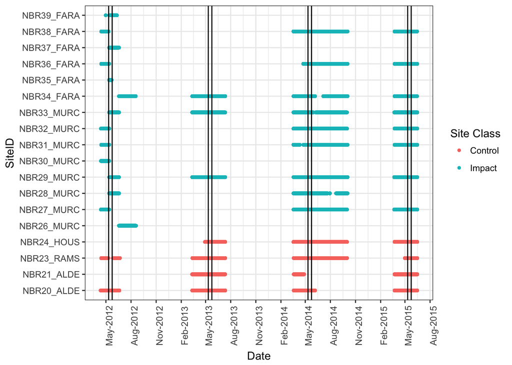

### Mean proportions by island

Figure 3: Phase 1, Ancient Murrelet; Mean proportion of recordings with detected presence (left panel) and more than one individual detected. Color indicates whether island was control or impact; shape indicates island group

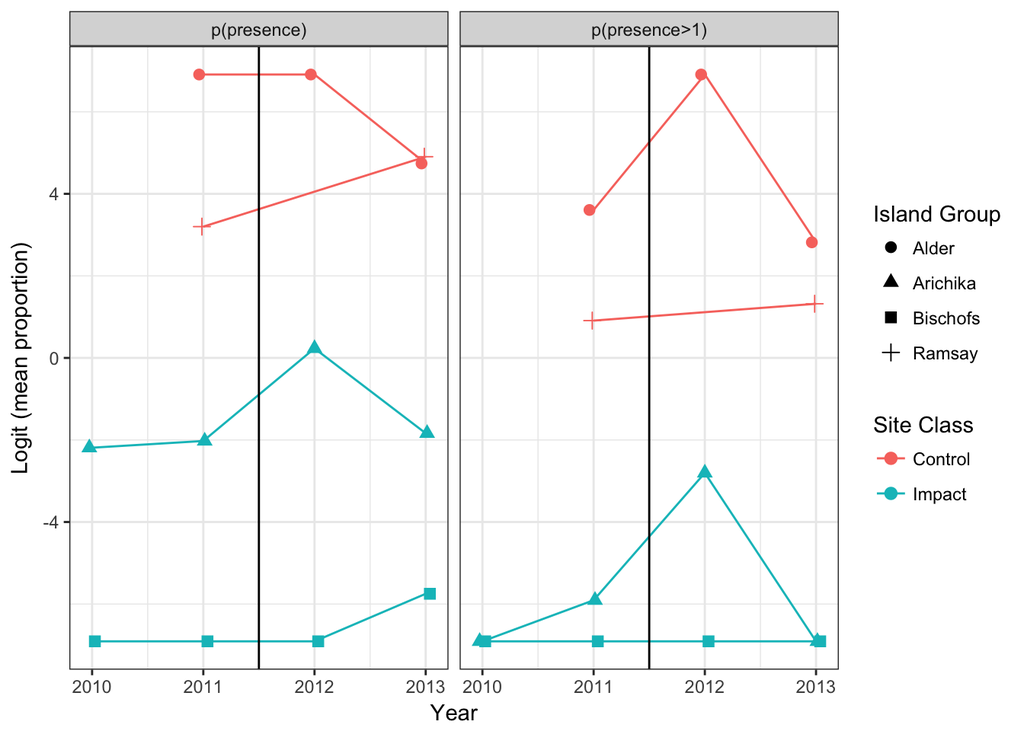

Figure 4: Phase 2, Ancient Murrelet; Mean proportion of recordings with detected presence (left panel) and more than one individual detected. Color indicates whether island was control or impact; shape indicates island group

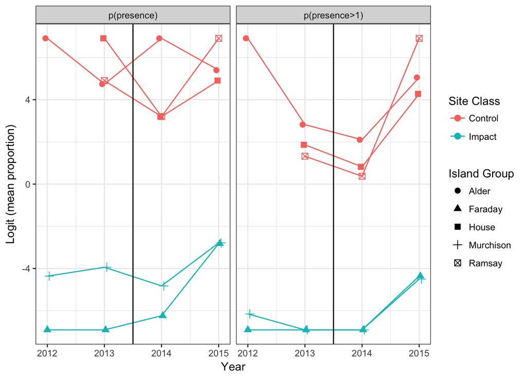

### Statistical model results

#### Phase 1, p(presence)

Table 1: Summary model coefficients; Ancient Murrelet, Phase 1, proportion of recordings with detected presence.

| Term | Estimate | SE | df | p-value |
| --- | --- | --- | --- | --- |
| Intercept | 0.327 | 1.389 | 2.1 | 0.835 |
| Period | 0.246 | 0.369 | 18.6 | 0.513 |
| Site Class | -6.166 | 1.964 | 2.1 | 0.083 |
| Period:SiteClass | 0.362 | 0.522 | 18.6 | 0.496 |

Table 2: BACI marginal means; Ancient Murrelet, Phase 1, proportion of recordings with detected presence.

| Site Class | Period | Marginal Mean | SE | df | Lower CL | Upper CL |
| --- | --- | --- | --- | --- | --- | --- |
| Control | Before | 4.694 | 2.080 | 2.6 | -2.484 | 11.871 |
| Impact | Before | -4.389 | 1.950 | 2.0 | -12.637 | 3.860 |
| Control | After | 4.680 | 2.014 | 2.3 | -2.945 | 12.304 |
| Impact | After | -3.678 | 1.947 | 2.0 | -11.958 | 4.602 |

Table 3: BACI effect and 95% confidence intervals; Ancient Murrelet, Phase 1, proportion of recordings with detected presence.

| Estimate | SE | df | Lower CL | Upper CL | p-value |
| --- | --- | --- | --- | --- | --- |
| -0.724 | 1.044 | 18.6 | -2.912 | 1.464 | 0.496 |

#### Phase 1, p(presence>1)

Table 4: Summary model coefficients; Ancient Murrelet, Phase 1, proportion of recordings with more than one individual detected.

| Term | Estimate | SE | df | p-value |
| --- | --- | --- | --- | --- |
| Intercept | -1.873 | 0.760 | 3.5 | 0.079 |
| Period | 0.711 | 0.786 | 2.7 | 0.439 |
| Site Class | -6.171 | 0.856 | 2.1 | 0.017 |
| Period:SiteClass | -0.639 | 0.611 | 19.0 | 0.309 |

Table 5: BACI marginal means; Ancient Murrelet, Phase 1, proportion of recordings with more than one individual detected.

| Site Class | Period | Marginal Mean | SE | df | Lower CL | Upper CL |
| --- | --- | --- | --- | --- | --- | --- |
| Control | Before | 1.668 | 1.362 | 8.3 | -1.455 | 4.792 |
| Impact | Before | -6.420 | 1.033 | 2.9 | -9.761 | -3.079 |
| Control | After | 3.313 | 1.188 | 5.1 | 0.274 | 6.353 |
| Impact | After | -6.053 | 1.026 | 2.9 | -9.400 | -2.706 |

Table 6: BACI effect and 95% confidence intervals; Ancient Murrelet, Phase 1, proportion of recordings with more than one individual detected.

| Estimate | SE | df | Lower CL | Upper CL | p-value |
| --- | --- | --- | --- | --- | --- |
| 1.278 | 1.222 | 19 | -1.28 | 3.836 | 0.309 |

#### Phase 2, p(presence)

Table 7: Summary model coefficients; Ancient Murrelet, Phase 2, proportion of recordings with detected presence.

| Term | Estimate | SE | df | p-value |
| --- | --- | --- | --- | --- |
| Intercept | 0.014 | 0.790 | 4.2 | 0.987 |
| Period | 0.179 | 0.895 | 2.1 | 0.859 |
| Site Class | -7.289 | 0.765 | 6.0 | 0.000 |
| Period:SiteClass | 1.066 | 0.507 | 25.8 | 0.045 |

Table 8: BACI marginal means; Ancient Murrelet, Phase 2, proportion of recordings with detected presence.

| Site Class | Period | Marginal Mean | SE | df | Lower CL | Upper CL |
| --- | --- | --- | --- | --- | --- | --- |
| Control | Before | 5.574 | 1.303 | 7.5 | 2.537 | 8.611 |
| Impact | Before | -5.800 | 1.079 | 3.6 | -8.950 | -2.650 |
| Control | After | 4.762 | 1.240 | 6.4 | 1.773 | 7.750 |
| Impact | After | -4.481 | 1.059 | 3.4 | -7.656 | -1.307 |

Table 9: BACI effect and 95% confidence intervals; Ancient Murrelet, Phase 2, proportion of recordings with detected presence.

| Estimate | SE | df | Lower CL | Upper CL | p-value |
| --- | --- | --- | --- | --- | --- |
| -2.131 | 1.014 | 25.8 | -4.215 | -0.047 | 0.045 |

#### Phase 2, p(presence>1)

Table 10: Summary model coefficients; Ancient Murrelet, Phase 2, proportion of recordings with more than one individual detected.

| Term | Estimate | SE | df | p-value |
| --- | --- | --- | --- | --- |
| Intercept | -1.567 | 0.910 | 2.4 | 0.207 |
| Period | 0.414 | 1.239 | 2.0 | 0.770 |
| Site Class | -6.853 | 0.516 | 18.2 | 0.000 |
| Period:SiteClass | 0.740 | 0.523 | 28.9 | 0.168 |

Table 11: BACI marginal means; Ancient Murrelet, Phase 2, proportion of recordings with more than one individual detected.

| Site Class | Period | Marginal Mean | SE | df | Lower CL | Upper CL |
| --- | --- | --- | --- | --- | --- | --- |
| Control | Before | 3.356 | 1.428 | 3.5 | -0.825 | 7.536 |
| Impact | Before | -7.076 | 1.291 | 2.4 | -11.850 | -2.301 |
| Control | After | 3.201 | 1.369 | 3.0 | -1.144 | 7.545 |
| Impact | After | -5.750 | 1.268 | 2.2 | -10.694 | -0.806 |

Table 12: BACI effect and 95% confidence intervals; Ancient Murrelet, Phase 2, proportion of recordings with more than one individual detected.

| Estimate | SE | df | Lower CL | Upper CL | p-value |
| --- | --- | --- | --- | --- | --- |
| -1.48 | 1.046 | 28.9 | -3.62 | 0.659 | 0.168 |

## Cassin’s Auklet

Figure 5: Phase 1 temporal coverage by site. Colour indicates site class (‘Control’, ‘Impact’). Vertical black lines indicate 2-week sampling window used for Cassin’s Auklet analysis (May 01 - May 14).

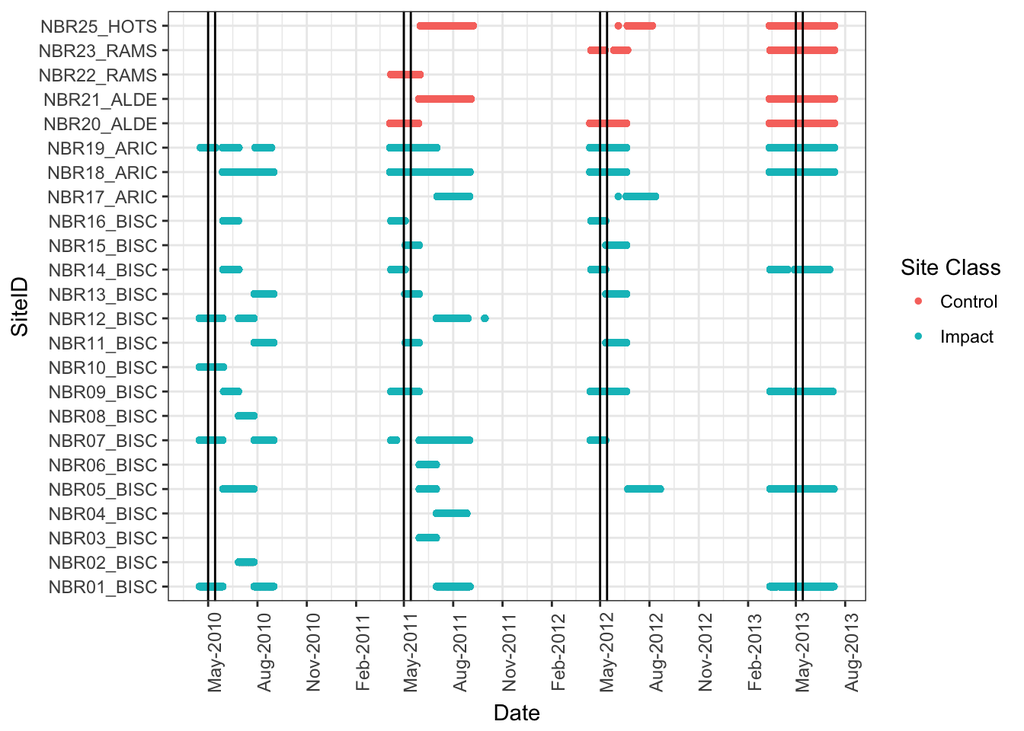

Figure 6: Phase 2 temporal coverage by site. Colour indicates site class (‘Control’, ‘Impact’). Vertical black lines indicate 2-week sampling window used for Cassin’s Auklet analysis (May 01 - May 14).

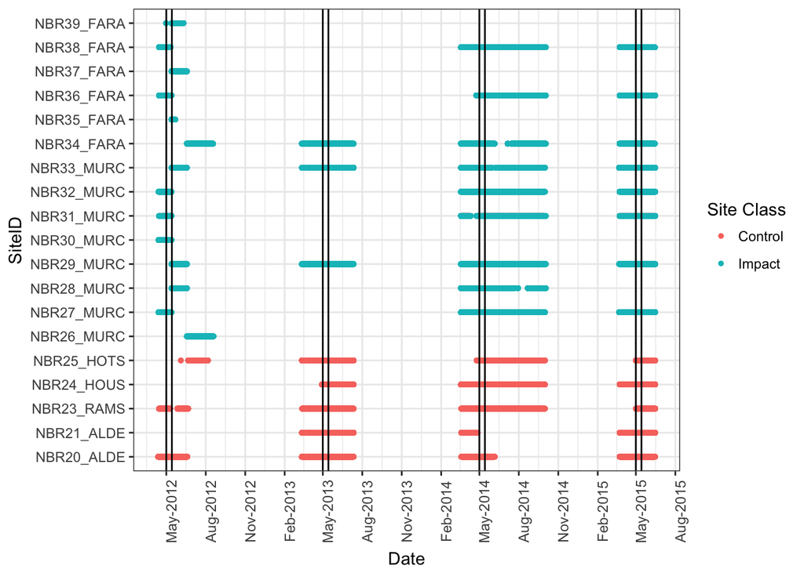

### Mean proportions by island

Figure 7: Phase 1, Cassin’s Auklet; Mean proportion of recordings with detected presence (left panel) and more than one individual detected. Color indicates whether island was control or impact; shape indicates island group

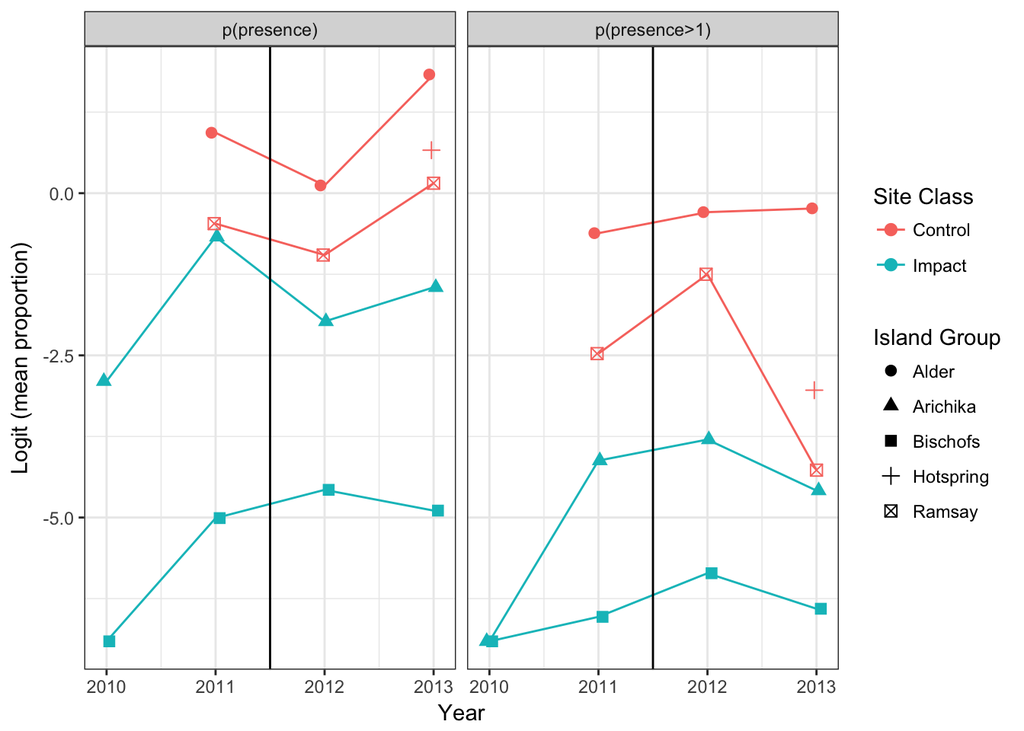

Figure 8: Phase 2, Cassin’s Auklet; Mean proportion of recordings with detected presence (left panel) and more than one individual detected. Color indicates whether island was control or impact; shape indicates island group

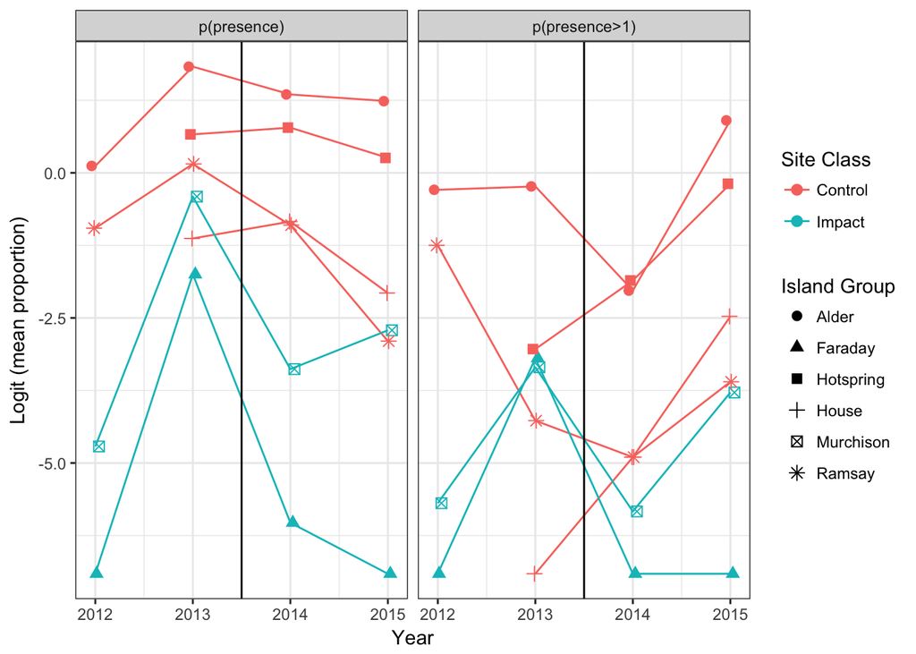

### Statistical model results

#### Phase 1, p(presence)

Table 13: Summary model coefficients; Cassin’s Auklet, Phase 1, proportion of recordings with detected presence.

| Term | Estimate | SE | df | p-value |
| --- | --- | --- | --- | --- |
| Intercept | -1.794 | 0.915 | 4.7 | 0.110 |
| Period | 0.681 | 0.740 | 2.4 | 0.441 |
| Site Class | -2.509 | 1.135 | 3.5 | 0.101 |
| Period:SiteClass | -0.016 | 0.569 | 28.6 | 0.978 |

Table 14: BACI marginal means; Cassin’s Auklet, Phase 1, proportion of recordings with detected presence.

| Site Class | Period | Marginal Mean | SE | df | Lower CL | Upper CL |
| --- | --- | --- | --- | --- | --- | --- |
| Control | Before | -0.509 | 1.485 | 10.1 | -3.812 | 2.794 |
| Impact | Before | -4.042 | 1.347 | 4.2 | -7.706 | -0.377 |
| Control | After | 0.470 | 1.239 | 5.6 | -2.620 | 3.560 |
| Impact | After | -3.094 | 1.338 | 4.1 | -6.769 | 0.581 |

Table 15: BACI effect and 95% confidence intervals; Cassin’s Auklet, Phase 1, proportion of recordings with detected presence.

| Estimate | SE | df | Lower CL | Upper CL | p-value |
| --- | --- | --- | --- | --- | --- |
| 0.031 | 1.137 | 28.6 | -2.296 | 2.358 | 0.978 |

#### Phase 1, p(presence>1)

Table 16: Summary model coefficients; Cassin’s Auklet, Phase 1, proportion of recordings with more than one individual detected.

| Term | Estimate | SE | df | p-value |
| --- | --- | --- | --- | --- |
| Intercept | -3.772 | 0.763 | 4.0 | 0.008 |
| Period | 0.420 | 0.573 | 2.3 | 0.531 |
| Site Class | -2.634 | 0.961 | 3.0 | 0.072 |
| Period:SiteClass | 0.112 | 0.414 | 23.2 | 0.789 |

Table 17: BACI marginal means; Cassin’s Auklet, Phase 1, proportion of recordings with more than one individual detected.

| Site Class | Period | Marginal Mean | SE | df | Lower CL | Upper CL |
| --- | --- | --- | --- | --- | --- | --- |
| Control | Before | -2.150 | 1.195 | 8.2 | -4.896 | 0.595 |
| Impact | Before | -5.987 | 1.122 | 3.5 | -9.302 | -2.672 |
| Control | After | -1.668 | 1.033 | 4.8 | -4.349 | 1.013 |
| Impact | After | -5.281 | 1.118 | 3.4 | -8.607 | -1.955 |

Table 18: BACI effect and 95% confidence intervals; Cassin’s Auklet, Phase 1, proportion of recordings with more than one individual detected.

| Estimate | SE | df | Lower CL | Upper CL | p-value |
| --- | --- | --- | --- | --- | --- |
| -0.224 | 0.827 | 23.2 | -1.934 | 1.487 | 0.789 |

#### Phase 2, p(presence)

Table 19: Summary model coefficients; Cassin’s Auklet, Phase 2, proportion of recordings with detected presence.

| Term | Estimate | SE | df | p-value |
| --- | --- | --- | --- | --- |
| Intercept | -2.436 | 0.862 | 5.2 | 0.035 |
| Period | -0.124 | 0.798 | 1.8 | 0.892 |
| Site Class | -3.196 | 0.970 | 4.4 | 0.026 |
| Period:SiteClass | -0.180 | 0.411 | 29.9 | 0.664 |

Table 20: BACI marginal means; Cassin’s Auklet, Phase 2, proportion of recordings with detected presence.

| Site Class | Period | Marginal Mean | SE | df | Lower CL | Upper CL |
| --- | --- | --- | --- | --- | --- | --- |
| Control | Before | -0.178 | 1.274 | 8.0 | -3.117 | 2.760 |
| Impact | Before | -4.518 | 1.254 | 4.3 | -7.913 | -1.123 |
| Control | After | -0.174 | 1.244 | 7.4 | -3.084 | 2.737 |
| Impact | After | -4.874 | 1.247 | 4.2 | -8.267 | -1.481 |

Table 21: BACI effect and 95% confidence intervals; Cassin’s Auklet, Phase 2, proportion of recordings with detected presence.

| Estimate | SE | df | Lower CL | Upper CL | p-value |
| --- | --- | --- | --- | --- | --- |
| 0.361 | 0.822 | 29.9 | -1.318 | 2.04 | 0.664 |

#### Phase 2, p(presence>1)

Table 22: Summary model coefficients; Cassin’s Auklet, Phase 2, proportion of recordings with more than one individual detected.

| Term | Estimate | SE | df | p-value |
| --- | --- | --- | --- | --- |
| Intercept | -4.132 | 0.794 | 3.5 | 0.009 |
| Period | 0.154 | 0.532 | 2.2 | 0.798 |
| Site Class | -2.578 | 1.030 | 2.7 | 0.097 |
| Period:SiteClass | -0.287 | 0.395 | 30.3 | 0.473 |

Table 23: BACI marginal means; Cassin’s Auklet, Phase 2, proportion of recordings with more than one individual detected.

| Site Class | Period | Marginal Mean | SE | df | Lower CL | Upper CL |
| --- | --- | --- | --- | --- | --- | --- |
| Control | Before | -2.561 | 1.149 | 7.7 | -5.232 | 0.109 |
| Impact | Before | -5.920 | 1.185 | 2.5 | -10.178 | -1.662 |
| Control | After | -2.057 | 1.118 | 7.0 | -4.700 | 0.586 |
| Impact | After | -5.989 | 1.180 | 2.5 | -10.265 | -1.714 |

Table 24: BACI effect and 95% confidence intervals; Cassin’s Auklet, Phase 2, proportion of recordings with more than one individual detected.

| Estimate | SE | df | Lower CL | Upper CL | p-value |
| --- | --- | --- | --- | --- | --- |
| 0.574 | 0.789 | 30.3 | -1.038 | 2.185 | 0.473 |

## Fork-Tailed Storm Petrel

Figure 9: Phase 1 temporal coverage by site. Colour indicates site class (‘Control’, ‘Impact’). Vertical black lines indicate 2-week sampling window used for Fork-Tailed Storm-Petrel analysis (May 01 - May 14).

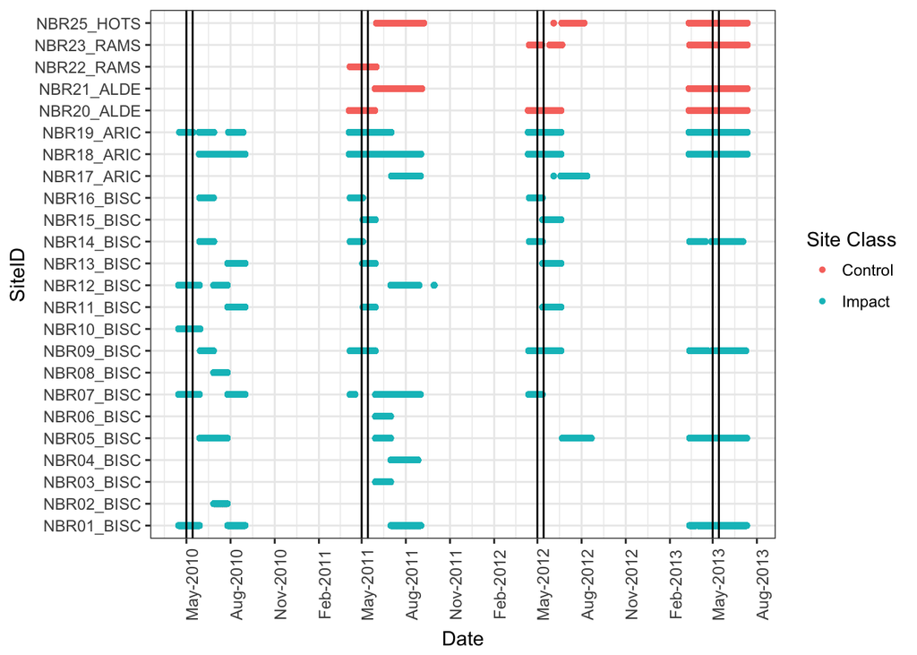

Figure 10: Phase 2 temporal coverage by site. Colour indicates site class (‘Control’, ‘Impact’). Vertical black lines indicate 2-week sampling window used for Fork-Tailed Storm-Petrel analysis (May 01 - May 14).

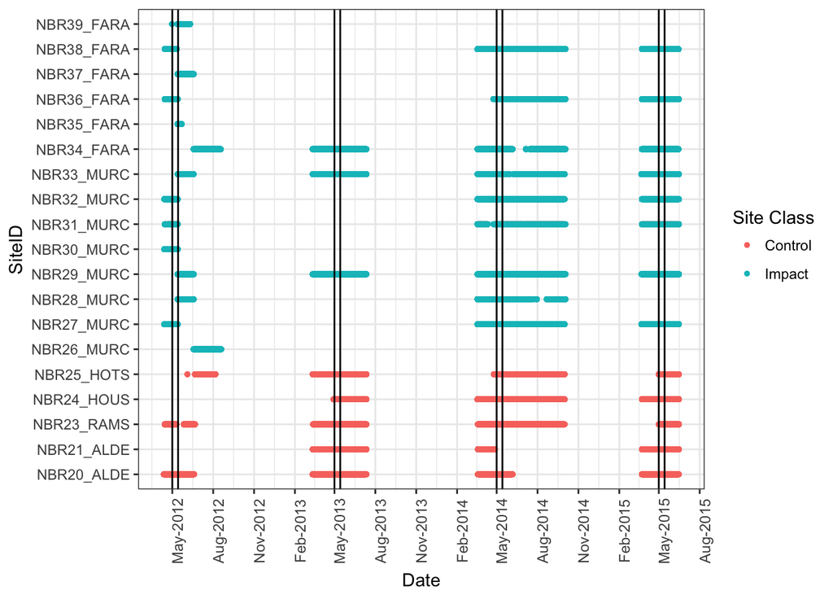

### Mean proportions by island

Figure 11: Phase 1, Fork-Tailed Storm-Petrel; Mean proportion of recordings with detected presence (left panel) and more than one individual detected. Color indicates whether island was control or impact; shape indicates island group

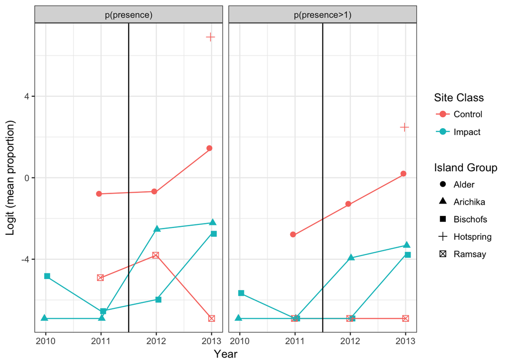

Figure 12: Phase 2, Fork-Tailed Storm-Petrel; Mean proportion of recordings with detected presence (left panel) and more than one individual detected. Color indicates whether island was control or impact; shape indicates island group

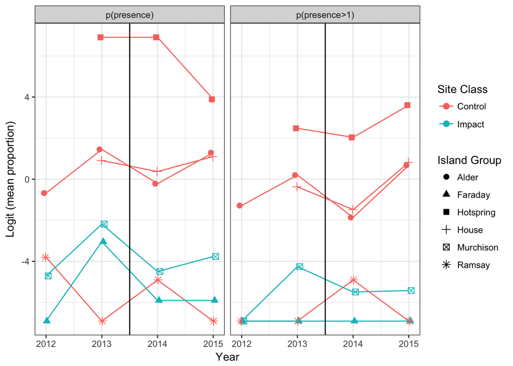

### Statistical model results

#### Phase 1, p(presence)

Table 25: Summary model coefficients; Fork-Tailed Storm-Petrel, Phase 1, proportion of recordings with detected presence.

| Term | Estimate | SE | df | p-value |
| --- | --- | --- | --- | --- |
| Intercept | -2.301 | 1.998 | 2.5 | 0.349 |
| Period | 0.955 | 0.718 | 3.2 | 0.270 |
| Site Class | -3.545 | 2.810 | 2.4 | 0.316 |
| Period:SiteClass | 0.468 | 0.918 | 25.3 | 0.615 |

Table 26: BACI marginal means; Fork-Tailed Storm-Petrel, Phase 1, proportion of recordings with detected presence.

| Site Class | Period | Marginal Mean | SE | df | Lower CL | Upper CL |
| --- | --- | --- | --- | --- | --- | --- |
| Control | Before | -0.236 | 2.928 | 4.4 | -8.113 | 7.640 |
| Impact | Before | -5.718 | 3.017 | 2.2 | -17.488 | 6.052 |
| Control | After | 0.647 | 2.626 | 2.9 | -7.901 | 9.194 |
| Impact | After | -3.899 | 3.010 | 2.2 | -15.726 | 7.929 |

Table 27: BACI effect and 95% confidence intervals; Fork-Tailed Storm-Petrel, Phase 1, proportion of recordings with detected presence.

| Estimate | SE | df | Lower CL | Upper CL | p-value |
| --- | --- | --- | --- | --- | --- |
| -0.936 | 1.836 | 25.3 | -4.716 | 2.844 | 0.615 |

#### Phase 1, p(presence>1)

Table 28: Summary model coefficients; Fork-Tailed Storm-Petrel, Phase 1, proportion of recordings with more than one individual detected.

| Term | Estimate | SE | df | p-value |
| --- | --- | --- | --- | --- |
| Intercept | -3.978 | 1.503 | 2.5 | 0.092 |
| Period | 1.074 | 0.485 | 4.2 | 0.087 |
| Site Class | -2.144 | 2.108 | 2.4 | 0.399 |
| Period:SiteClass | -0.342 | 0.548 | 19.8 | 0.540 |

Table 29: BACI marginal means; Fork-Tailed Storm-Petrel, Phase 1, proportion of recordings with more than one individual detected.

| Site Class | Period | Marginal Mean | SE | df | Lower CL | Upper CL |
| --- | --- | --- | --- | --- | --- | --- |
| Control | Before | -3.392 | 2.142 | 4.0 | -9.328 | 2.544 |
| Impact | Before | -6.082 | 2.251 | 2.2 | -14.940 | 2.776 |
| Control | After | -1.532 | 1.995 | 3.1 | -7.782 | 4.718 |
| Impact | After | -4.905 | 2.249 | 2.2 | -13.783 | 3.972 |

Table 30: BACI effect and 95% confidence intervals; Fork-Tailed Storm-Petrel, Phase 1, proportion of recordings with more than one individual detected.

| Estimate | SE | df | Lower CL | Upper CL | p-value |
| --- | --- | --- | --- | --- | --- |
| 0.683 | 1.096 | 19.8 | -1.604 | 2.97 | 0.54 |

#### Phase 2, p(presence)

Table 31: Summary model coefficients; Fork-Tailed Storm-Petrel, Phase 2, proportion of recordings with detected presence.

| Term | Estimate | SE | df | p-value |
| --- | --- | --- | --- | --- |
| Intercept | -2.387 | 1.670 | 3.2 | 0.243 |
| Period | -0.121 | 0.261 | 30.3 | 0.646 |
| Site Class | -4.197 | 2.362 | 3.2 | 0.168 |
| Period:SiteClass | 0.227 | 0.368 | 30.3 | 0.542 |

Table 32: BACI marginal means; Fork-Tailed Storm-Petrel, Phase 2, proportion of recordings with detected presence.

| Site Class | Period | Marginal Mean | SE | df | Lower CL | Upper CL |
| --- | --- | --- | --- | --- | --- | --- |
| Control | Before | 0.780 | 2.045 | 4.0 | -4.873 | 6.433 |
| Impact | Before | -5.382 | 2.670 | 2.9 | -14.027 | 3.262 |
| Control | After | 0.382 | 2.031 | 3.9 | -5.291 | 6.056 |
| Impact | After | -5.327 | 2.674 | 2.9 | -13.953 | 3.300 |

Table 33: BACI effect and 95% confidence intervals; Fork-Tailed Storm-Petrel, Phase 2, proportion of recordings with detected presence.

| Estimate | SE | df | Lower CL | Upper CL | p-value |
| --- | --- | --- | --- | --- | --- |
| -0.454 | 0.737 | 30.3 | -1.958 | 1.05 | 0.542 |

#### Phase 2, p(presence>1)

Table 34: Summary model coefficients; Fork-Tailed Storm-Petrel, Phase 2, proportion of recordings with more than one individual detected.

| Term | Estimate | SE | df | p-value |
| --- | --- | --- | --- | --- |
| Intercept | -3.718 | 1.387 | 3.8 | 0.059 |
| Period | 0.347 | 0.365 | 1.3 | 0.482 |
| Site Class | -3.683 | 1.943 | 3.6 | 0.138 |
| Period:SiteClass | -0.029 | 0.346 | 30.4 | 0.934 |

Table 35: BACI marginal means; Fork-Tailed Storm-Petrel, Phase 2, proportion of recordings with more than one individual detected.

| Site Class | Period | Marginal Mean | SE | df | Lower CL | Upper CL |
| --- | --- | --- | --- | --- | --- | --- |
| Control | Before | -1.373 | 1.675 | 4.5 | -5.827 | 3.082 |
| Impact | Before | -6.553 | 2.246 | 3.6 | -13.039 | -0.066 |
| Control | After | -0.854 | 1.658 | 4.3 | -5.324 | 3.617 |
| Impact | After | -6.091 | 2.244 | 3.6 | -12.582 | 0.400 |

Table 36: BACI effect and 95% confidence intervals; Fork-Tailed Storm-Petrel, Phase 2, proportion of recordings with more than one individual detected.

| Estimate | SE | df | Lower CL | Upper CL | p-value |
| --- | --- | --- | --- | --- | --- |
| 0.058 | 0.691 | 30.4 | -1.353 | 1.468 | 0.934 |